# Answering Some Basic Questions About Severe Weather Events Using the NOAA Storm Database

Eric Bratt

23 November 2014

## 0.1 Synopsis

The U.S. National Oceanic and Atmospheric Administration’s (NOAA) storm database tracks characteristics of major storms and weather events in the United States, including when and where they occur, as well as estimates of any fatalities, injuries, and property damage. The events in the database correspond to 902,297 observations starting in the year 1950 and ending in November 2011. The data can be found here:

http://d396qusza40orc.cloudfront.net/repdata%2Fdata%2FStormData.csv.bz2

This report addresses the questions:

1. Across the United States, which types of events are most harmful with respect to population health?
2. Across the United States, which types of events have the greatest economic consequences?

This report was created for the course *http://class.coursera.org/repdata-008* on the following environment:

```
               _
platform       i386-w64-mingw32
arch           i386
os             mingw32
system         i386, mingw32
status
major          3
minor          1.1
year           2014
month          07
day            10
svn rev        66115
language       R
version.string R version 3.1.1 (2014-07-10)
nickname       Sock it to Me
```

## 0.2 Downloading the directive

1. Download the NOAA study’s documentation in PDF form. This file contains information about the study and the variable descriptions in the data.
2. Download the NOAA study’s frequently asked questions guide in PDF form. This file contains codes, abbreviations, and notes regarding the database.

```r
docURL <- "http://d396qusza40orc.cloudfront.net/repdata%2Fpeer2_doc%2Fpd01016005curr.pdf"
if (!file.exists("doc.pdf")) {
    os <- (Sys.info()[['sysname']])
    if (os == 'Windows') {
        download.file(docURL, destfile="doc.pdf", quiet=T, mode='wb')
    }
    else {
        download.file(docURL, destfile="doc.pdf", method='curl', quiet=T, mode='wb')
    }
}
faqURL <- "http://d396qusza40orc.cloudfront.net/repdata%2Fpeer2_doc%2FNCDC%20Storm%20Events-FAQ%20Page.pdf"
if (!file.exists("faq.pdf")) {
    os <- (Sys.info()[['sysname']])
    if (os == 'Windows') {
        download.file(faqURL, destfile="faq.pdf", quiet=T, mode='wb')
    }
    else {
        download.file(faqURL, destfile="faq.pdf", method='curl', quiet=T, mode='wb')
    }
}
```

## 0.3 Data Processing

1. Download the NOAA database in raw and compressed (.bz2) form. This will check the operating system type and if the OS is not Windows, then it uses method=‘curl’.
2. Read the bz2 file as csv into an R dataframe.

```r
fileURL <- "http://d396qusza40orc.cloudfront.net/repdata%2Fdata%2FStormData.csv.bz2"
dateDownloaded <- date()
if (!file.exists("data")) {
    dir.create("data")
}
if (!file.exists("data/StormData.csv.bz2")) {
    if (os == 'Windows') {
        download.file(fileURL, destfile="data/StormData.csv.bz2", quiet=T)
    }
    else {
        download.file(fileURL, destfile="data/StormData.csv.bz2", method="curl", quiet=T)
    }
}
if (!suppressWarnings(require("R.utils"))) {
    install.packages("R.utils")
    library(R.utils)
}
```

[output not shown]

```r
if (!exists("data")) {
    data <- read.csv(bzfile("data/StormData.csv.bz2"),
                     header = TRUE,
                     stringsAsFactors=FALSE)
}
```

## 0.4 Analysis

Which types of events are most harmful with respect to population health? How many unique event types are there in the data?

```r
numeventtypes <- length(table(data$EVTYPE))
print(numeventtypes, type='html', include.rownames=FALSE)
```

[1] 985

There are 985 unique event types in the data, and many of these event types are duplications with different unique names. Additionally, it was provided by Dr. Peng that:

“In the earlier years of the database there are generally fewer events recorded, most likely due to a lack of good records. More recent years should be considered more complete.”

```r
if (!suppressWarnings(require("qcc"))) {
    install.packages("qcc")
    library(qcc)
}
```

```
NA Loading required package: qcc
NA Package 'qcc', version 2.6
NA Type 'citation("qcc")' for citing this R package in publications.
```

```r
year <- as.numeric(format(as.Date(data$BGN_DATE, format="%m/%d/%Y"), "%Y"))
if (!suppressWarnings(require("xtable"))) {
    install.packages("xtable")
    library(xtable)
}
```

```
NA Loading required package: xtable
```

```r
xtbl_year <- xtable(pareto.chart(table(year), plot=FALSE))
print(xtbl_year, type='html')
```

|  | Frequency | Cum.Freq. | Percentage | Cum.Percent. |
| --- | --- | --- | --- | --- |
| 2011 | 62174.00 | 62174.00 | 6.89 | 6.89 |
| 2008 | 55663.00 | 117837.00 | 6.17 | 13.06 |
| 2010 | 48161.00 | 165998.00 | 5.34 | 18.40 |
| 2009 | 45817.00 | 211815.00 | 5.08 | 23.48 |
| 2006 | 44034.00 | 255849.00 | 4.88 | 28.36 |
| 2007 | 43289.00 | 299138.00 | 4.80 | 33.15 |
| 2003 | 39752.00 | 338890.00 | 4.41 | 37.56 |
| 2004 | 39363.00 | 378253.00 | 4.36 | 41.92 |
| 2005 | 39184.00 | 417437.00 | 4.34 | 46.26 |
| 1998 | 38128.00 | 455565.00 | 4.23 | 50.49 |
| 2002 | 36293.00 | 491858.00 | 4.02 | 54.51 |
| 2001 | 34962.00 | 526820.00 | 3.87 | 58.39 |
| 2000 | 34471.00 | 561291.00 | 3.82 | 62.21 |
| 1996 | 32270.00 | 593561.00 | 3.58 | 65.78 |
| 1999 | 31289.00 | 624850.00 | 3.47 | 69.25 |
| 1997 | 28680.00 | 653530.00 | 3.18 | 72.43 |
| 1995 | 27970.00 | 681500.00 | 3.10 | 75.53 |
| 1994 | 20631.00 | 702131.00 | 2.29 | 77.82 |
| 1992 | 13534.00 | 715665.00 | 1.50 | 79.32 |
| 1993 | 12607.00 | 728272.00 | 1.40 | 80.71 |
| 1991 | 12522.00 | 740794.00 | 1.39 | 82.10 |
| 1990 | 10946.00 | 751740.00 | 1.21 | 83.31 |
| 1989 | 10410.00 | 762150.00 | 1.15 | 84.47 |
| 1986 | 8726.00 | 770876.00 | 0.97 | 85.43 |
| 1983 | 8322.00 | 779198.00 | 0.92 | 86.36 |
| 1985 | 7979.00 | 787177.00 | 0.88 | 87.24 |
| 1987 | 7367.00 | 794544.00 | 0.82 | 88.06 |
| 1984 | 7335.00 | 801879.00 | 0.81 | 88.87 |
| 1988 | 7257.00 | 809136.00 | 0.80 | 89.68 |
| 1982 | 7132.00 | 816268.00 | 0.79 | 90.47 |
| 1980 | 6146.00 | 822414.00 | 0.68 | 91.15 |
| 1974 | 5386.00 | 827800.00 | 0.60 | 91.74 |
| 1975 | 4975.00 | 832775.00 | 0.55 | 92.29 |
| 1981 | 4517.00 | 837292.00 | 0.50 | 92.80 |
| 1973 | 4463.00 | 841755.00 | 0.49 | 93.29 |
| 1979 | 4279.00 | 846034.00 | 0.47 | 93.76 |
| 1976 | 3768.00 | 849802.00 | 0.42 | 94.18 |
| 1977 | 3728.00 | 853530.00 | 0.41 | 94.60 |
| 1978 | 3657.00 | 857187.00 | 0.41 | 95.00 |
| 1971 | 3471.00 | 860658.00 | 0.38 | 95.39 |
| 1968 | 3312.00 | 863970.00 | 0.37 | 95.75 |
| 1970 | 3215.00 | 867185.00 | 0.36 | 96.11 |
| 1969 | 2926.00 | 870111.00 | 0.32 | 96.43 |
| 1965 | 2855.00 | 872966.00 | 0.32 | 96.75 |
| 1967 | 2688.00 | 875654.00 | 0.30 | 97.05 |
| 1962 | 2389.00 | 878043.00 | 0.26 | 97.31 |
| 1966 | 2388.00 | 880431.00 | 0.26 | 97.58 |
| 1964 | 2348.00 | 882779.00 | 0.26 | 97.84 |
| 1961 | 2246.00 | 885025.00 | 0.25 | 98.09 |
| 1958 | 2213.00 | 887238.00 | 0.25 | 98.33 |
| 1957 | 2184.00 | 889422.00 | 0.24 | 98.57 |
| 1972 | 2168.00 | 891590.00 | 0.24 | 98.81 |
| 1963 | 1968.00 | 893558.00 | 0.22 | 99.03 |
| 1960 | 1945.00 | 895503.00 | 0.22 | 99.25 |
| 1959 | 1813.00 | 897316.00 | 0.20 | 99.45 |
| 1956 | 1703.00 | 899019.00 | 0.19 | 99.64 |
| 1955 | 1413.00 | 900432.00 | 0.16 | 99.79 |
| 1954 | 609.00 | 901041.00 | 0.07 | 99.86 |
| 1953 | 492.00 | 901533.00 | 0.05 | 99.92 |
| 1952 | 272.00 | 901805.00 | 0.03 | 99.95 |
| 1951 | 269.00 | 902074.00 | 0.03 | 99.98 |
| 1950 | 223.00 | 902297.00 | 0.02 | 100.00 |

It looks like 80% of the observations fall between the years 1992 and 2011. Therefore, we decided to limit the analysis to the years 1992 through 2011. As such, we select all rows where the *BGN_DATE* is between 1992 and 2011. Additionally, we only care about the date of the event, event type, number of fatalities and injuries, and amount of property and crop damage. As such, we will limit the selected fields to the following:

- BGN_DATE
- EVTYPE
- FATALITIES
- INJURIES
- PROPDMG
- PROPDMGEXP
- CROPDMG
- CROPDMGEXP

```r
data <- subset(data, BGN_DATE > as.Date('12/31/1991', format='%m/%d/%Y'))
cols <- c("BGN_DATE", "EVTYPE", "FATALITIES", "INJURIES", "PROPDMG",
          "PROPDMGEXP", "CROPDMG", "CROPDMGEXP")
data <- data[cols]
```

Now we are ready to look at the events that caused the most fatalities between 1992 and 2011:

```r
if (!suppressWarnings(require("dplyr"))) {
    install.packages("dplyr")
    library(dplyr)
}
topfatals <- data %.%
    group_by(EVTYPE) %.%
    summarize(n=sum(FATALITIES)) %.%
    mutate(proportion=n/sum(n)) %.%
    arrange(desc(proportion))
top10fatals <- as.data.frame(head(topfatals,10))
xtbl_fatals <- xtable(top10fatals)
print(xtbl_fatals, type='html', include.rownames=FALSE)
```

| EVTYPE | n | proportion |
| --- | --- | --- |
| EXCESSIVE HEAT | 1894.00 | 0.24 |
| TORNADO | 1750.00 | 0.22 |
| HEAT | 936.00 | 0.12 |
| LIGHTNING | 722.00 | 0.09 |
| FLASH FLOOD | 658.00 | 0.08 |
| TSTM WIND | 371.00 | 0.05 |
| RIP CURRENT | 271.00 | 0.03 |
| FLOOD | 187.00 | 0.02 |
| HEAT WAVE | 172.00 | 0.02 |
| RIP CURRENTS | 122.00 | 0.02 |

And we can also look at the events that caused the most injuries between 1992 and 2011:

```r
topinjuries <- data %.%
    group_by(EVTYPE) %.%
    summarize(n=sum(INJURIES)) %.%
    mutate(proportion=n/sum(n)) %.%
    arrange(desc(proportion))
top10injuries <- as.data.frame(head(topinjuries, 10))
xtbl_injuries <- xtable(top10injuries)
print(xtbl_injuries, type='html', include.rownames=FALSE)
```

| EVTYPE | n | proportion |
| --- | --- | --- |
| TORNADO | 28702.00 | 0.52 |
| EXCESSIVE HEAT | 6525.00 | 0.12 |
| TSTM WIND | 4683.00 | 0.08 |
| LIGHTNING | 4578.00 | 0.08 |
| HEAT | 2096.00 | 0.04 |
| FLASH FLOOD | 1330.00 | 0.02 |
| THUNDERSTORM WIND | 1107.00 | 0.02 |
| HAIL | 1041.00 | 0.02 |
| HURRICANE/TYPHOON | 933.00 | 0.02 |
| THUNDERSTORM WINDS | 632.00 | 0.01 |

According to page 12 of the directive, in an attempt to save space in the data:

“Estimates should be rounded to three significant digits, followed by an alphabetical character signifying the magnitude of the number, i.e., 1.55B for $1,550,000,000. Alphabetical characters used to signify magnitude include “K” for thousands, “M” for millions, and “B” for billions.”

However, when we summarize the *PROPDMGEXP* and *CROPDMGEXP* columns, we see that there are identifiers that are not included in the documentation:

```r
print(xtable(as.data.frame(t(summary(data$PROPDMGEXP)))), type='html')
```

[output not shown]

```r
print(xtable(as.data.frame(t(summary(data$CROPDMGEXP)))), type='html')
```

|  | V1 | ? | 0 | 2 | B | k | K | m | M |
| --- | --- | --- | --- | --- | --- | --- | --- | --- | --- |
| 1 | 396836 | 2 | 8 | 1 | 7 | 3 | 171303 | 0 | 1505 |

```r
data$PROPDMG[which(data$PROPDMGEXP %in% c('h','H'))] <-
    data$PROPDMG[which(data$PROPDMGEXP %in% c('h','H'))]*10^2
data$PROPDMG[which(data$PROPDMGEXP %in% c('k','K'))] <-
    data$PROPDMG[which(data$PROPDMGEXP %in% c('k','K'))]*10^3
data$PROPDMG[which(data$PROPDMGEXP %in% c('m','M'))] <-
    data$PROPDMG[which(data$PROPDMGEXP %in% c('m','M'))]*10^6
data$PROPDMG[which(data$PROPDMGEXP %in% c('b','B'))] <-
    data$PROPDMG[which(data$PROPDMGEXP %in% c('b','B'))]*10^9
```

And now we can look at the events that caused the most economic damages between 1992 and 2011:

```r
topdamages <- data %.%
    group_by(EVTYPE) %.%
    summarize(n=sum(PROPDMG + CROPDMG)) %.%
    mutate(proportion=n/sum(n)) %.%
    arrange(desc(proportion))
top10damages <- as.data.frame(head(topdamages, 10))
xtbl_damages <- xtable(top10damages)
print(xtbl_damages, type='html', include.rownames=FALSE)
```

| EVTYPE | n | proportion |
| --- | --- | --- |
| HURRICANE/TYPHOON | 58856093646.48 | 0.29 |
| STORM SURGE | 43150368005.00 | 0.21 |
| TORNADO | 23763897052.29 | 0.12 |
| FLASH FLOOD | 13030085264.26 | 0.06 |
| HURRICANE | 10853181769.31 | 0.05 |
| FLOOD | 10163097858.08 | 0.05 |
| TROPICAL STORM | 7597574797.62 | 0.04 |
| HAIL | 6025503023.99 | 0.03 |
| RIVER FLOOD | 5031606060.00 | 0.02 |
| STORM SURGE/TIDE | 4635686000.00 | 0.02 |

Now we can plot the top 10 event types for each of fatalities, injuries, and economic damages in a Pareto chart to really *see* which ones are the worst:

```r
pareto.chart(xtabs(n ~ EVTYPE,
                   data = top10fatals,
                   drop.unused.levels = TRUE),
             ylab = "Fatalities",
             ylab2 = "Cumulative Percentage",
             cumperc = seq(0, 100, by = 20),
             main = "Pareto Chart for Events Causing Fatalities")
```

```
Pareto chart analysis for xtabs(n ~ EVTYPE, data = top10fatals, drop.unused.levels = TRUE)
                 Frequency Cum.Freq. Percentage Cum.Percent.
  EXCESSIVE HEAT      1894      1894  26.740082     26.74008
  TORNADO             1750      3644  24.707045     51.44713
  HEAT                 936      4580  13.214740     64.66187
  LIGHTNING            722      5302  10.193421     74.85529
  FLASH FLOOD          658      5960   9.289849     84.14514
  TSTM WIND            371      6331   5.237894     89.38303
  RIP CURRENT          271      6602   3.826062     93.20909
  FLOOD                187      6789   2.640124     95.84922
  HEAT WAVE            172      6961   2.428350     98.27757
  RIP CURRENTS         122      7083   1.722434    100.00000
```

```r
abline(h=(sum(top10fatals$n)*.8),col="red",lwd=4)
```

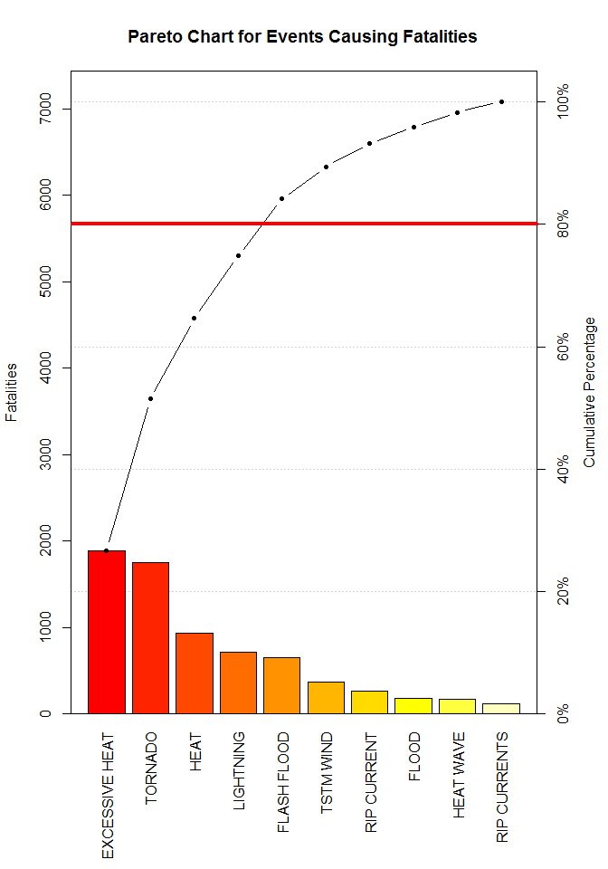

```r
pareto.chart(xtabs(n ~ EVTYPE,
                   data = top10injuries,
                   drop.unused.levels = TRUE),
             ylab = "Injuries",
             ylab2 = "Cumulative Percentage",
             cumperc = seq(0, 100, by = 20),
             main = "Pareto Chart for Events Causing Injuries")
```

```
Pareto chart analysis for xtabs(n ~ EVTYPE, data = top10injuries, drop.unused.levels = TRUE)
                     Frequency Cum.Freq. Percentage Cum.Percent.
  TORNADO                28702     28702  55.594941     55.59494
  EXCESSIVE HEAT          6525     35227  12.638736     68.23368
  TSTM WIND               4683     39910   9.070835     77.30451
  LIGHTNING               4578     44488   8.867453     86.17196
  HEAT                    2096     46584   4.059891     90.23186
  FLASH FLOOD             1330     47914   2.576171     92.80803
  THUNDERSTORM WIND       1107     49021   2.144227     94.95225
  HAIL                    1041     50062   2.016387     96.96864
  HURRICANE/TYPHOON        933     50995   1.807194     98.77583
  THUNDERSTORM WINDS       632     51627   1.224166    100.00000
```

```r
abline(h=(sum(top10injuries$n)*.8),col="red",lwd=4)
```

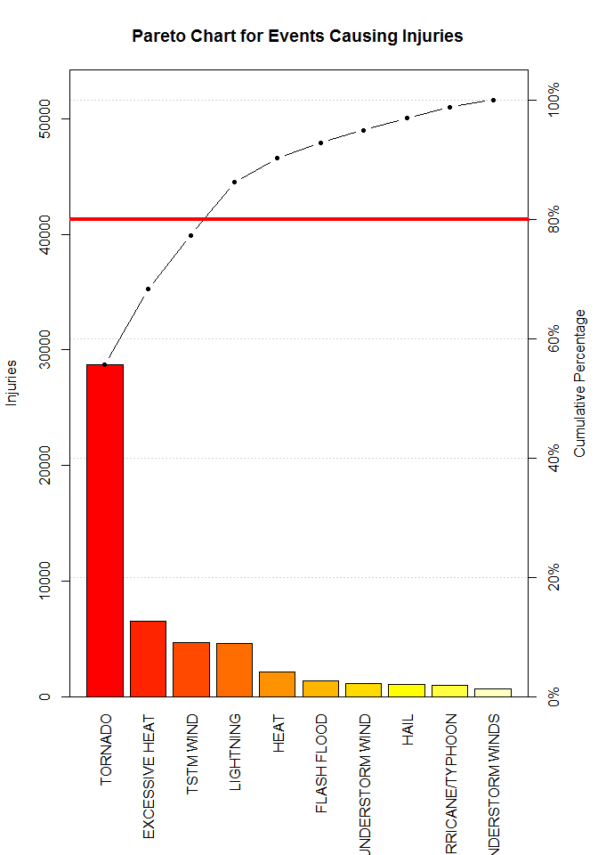

```r
pareto.chart(xtabs(n ~ EVTYPE,
                   data = top10damages,
                   drop.unused.levels = TRUE),
             ylab = "Damages (in $'s)",
             ylab2 = "Cumulative Percentage",
             cumperc = seq(0, 100, by = 20),
             main = "Pareto Chart for Events Causing Damages")
```

```
Pareto chart analysis for xtabs(n ~ EVTYPE, data = top10damages, drop.unused.levels = TRUE)
                      Frequency    Cum.Freq. Percentage Cum.Percent.
  HURRICANE/TYPHOON 58856093646  58856093646  32.142989     32.14299
  STORM SURGE       43150368005 102006461651  23.565645     55.70863
  TORNADO           23763897052 125770358704  12.978141     68.68678
  FLASH FLOOD       13030085264 138800443968   7.116101     75.80288
  HURRICANE         10853181769 149653625737   5.927232     81.73011
  FLOOD             10163097858 159816723595   5.550357     87.28047
  TROPICAL STORM     7597574798 167414298393   4.149252     91.42972
  HAIL               6025503024 173439801417   3.290699     94.72042
  RIVER FLOOD        5031606060 178471407477   2.747903     97.46832
  STORM SURGE/TIDE   4635686000 183107093477   2.531680    100.00000
```

```r
abline(h=(sum(top10damages$n)*.8),col="red",lwd=4)
```

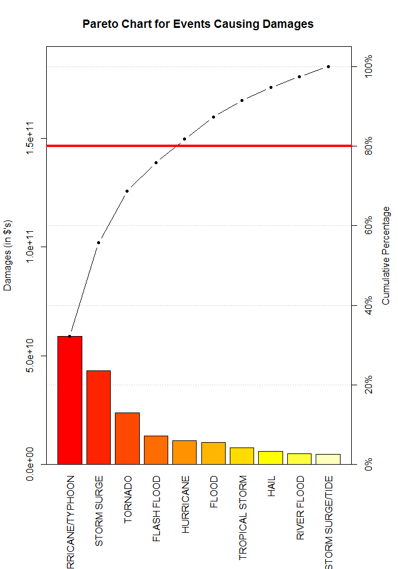

## 0.5 Results

Between 1992 and 2011, *EXCESSIVE HEAT* is the event type that caused the most fatalities, *TORNADO* is the event type that caused the most injuries, and *HURRICANE/TYPHOON* is the event type that caused the most economic damages to property and crops.

qcc package library created by:  
Scrucca, L. (2004). qcc: an R package for quality control charting and statistical process control. R News 4/1, 11-17.